# Cornell College R Workshop 2022

## Functions

You’ve been using R functions, now it’s time to write your own!

Let’s start simple. Here is a function that takes in an argument `x`, and adds 2 to it.

```r
add_two <- function(x){
  x + 2
}
```

Let’s test it:

```r
add_two(3)
```

```
## [1] 5
```

```r
add_two(10)
```

```
## [1] 12
```

The skeleton for defining functions in R is as follows:

```r
function_name <- function(input){
  # do something with the input(s)
  # return something
}
```

Then, a function for scraping a page should look something like:

**Hint:** Function names should be short but evocative verbs.

```r
function_name <- function(url){
  # read page at url
  # extract title, link, artist info for n pieces on page
  # return a n x 3 tibble
}
```

Our function uses the code you already developed earlier. We name the function `scrape_page`.

```r
scrape_page <- function(url){

  # read page
  page <- read_html(url)

  # scrape titles

  titles <- page %>%
html_nodes(".iteminfo") %>%
  html_node("h3 a") %>%
  html_text() %>%
  str_squish()
titles

  # scrape links

  links <- page %>%
html_nodes(".iteminfo") %>%
  html_node("h3 a") %>%
  html_attr("href") %>%
  str_replace("\\.", "https://collections.ed.ac.uk/art")
links

  # scrape artists

artists <- page %>%
  html_nodes(".iteminfo") %>%
  html_node(".artist") %>%
  html_text()
artists

  # create and return tibble
  tibble(
  title = titles,
  artist = artists,
  link = links
  )

}
```

When you run this chunk, check out the “Environment” tab of the top right panel. There should now be a new category called “Functions”

Test out your new function by running the following in the console. *You will need to copy and paste the URL’s from the first and second web pages we used before

Does the output look right?

Discuss with table-mates whether you’re getting the same results as before.

```r
scrape_page(____first_URL______)
scrape_page(____second_URL_____)
```

## Iteration

We went from manually scraping individual pages to writing a function to do the same. Next, we will work on making our workflow a little more efficient by using R to iterate over all pages that contain information on the art collection.

**Reminder:** The collection has 2970 pieces in total.

That means we give develop a list of URLs (of pages that each have 10 art pieces), and write some code that applies the `scrape_page()` function to each page, and combines the resulting data frames from each page into a single data frame with 2970 rows and 3 columns.

### List of URLs

Click through the first few of the pages in the art collection and observe their URLs to confirm the following pattern:

```
[sometext]offset=0     # Pieces 1-10
[sometext]offset=10    # Pieces 11-20
[sometext]offset=20    # Pieces 21-30
[sometext]offset=30    # Pieces 31-40
...
[sometext]offset=2960  # Pieces 2961-2970
```

Two new functions are helpful for accomplishing this: `glue()` for pasting two pieces of text and `seq()` for generating a sequence of numbers.

Fill in the blanks to construct the list of URLs.

```r
root <- "https://collections.ed.ac.uk/art/search/*:*/Collection:%22edinburgh+college+of+art%7C%7C%7CEdinburgh+College+of+Art%22?offset="
numbers <- seq(from = ___, to = ___, by = ___)
urls <- glue("{___}{___}")
```

### Mapping

Finally, we’re ready to iterate over the list of URLs we constructed. We will do this by **map**ping the function we developed over the list of URLs. There are a series of mapping functions in R, and they each take the following form:

```
map([x], [function to apply to each element of x])
```

In our case `x` is the list of URLs we constructed and the function to apply to each element of `x` is the function we developed earlier, `scrape_page`. And as a result we want a data frame, so we use `map_dfr` function:

```r
map_dfr(urls, scrape_page) #this applies a function to the urls object
```

Fill in the blanks to scrape all pages, and to create a new data frame called `uoe_art`.

```r
uoe_art <- map_dfr(__objects_we_want_to_apply_function_to___, ___our_function_name___)
```

### Write out data

Finally write out the data frame we constructed into the `data` folder so that you can use it in the analysis section.

```r
write_csv(uoe_art, file = "data/uoe-art.csv")
```

## Analysis

First, often you would clean up your R and before startign this stage. Let’s do that. In the top right panel, click *environment*. Next click the little *broom*. This will clean out your environment. Note that if you did not save code creating something that that something will now be gone.

Now that we have a tidy dataset that we can analyze, let’s do that! We nead to readin packges and the data we created.

### Load packages and data

```r
library(tidyverse)
library(skimr)
```

```r
# Remove eval = FALSE or set it to TRUE once data is ready to be loaded
uoe_art <- read_csv("data/uoe-art.csv")
```

We’ll start with some data cleaning, to clean up the dates that appear at the end of some title text in parentheses. Some of these are years, others are more specific dates, some art pieces have no date information whatsoever, and others have some non-date information in parentheses.

This should be interesting to clean up!

First thing we’ll try is to separate the `title` column into two: one for the actual `title` and the other for the `date` if it exists. In human speak, we need to

> “separate the `title` column at the first occurrence of `(` and put the contents on one side of the `(` into a column called `title` and the contents on the other side into a column called `date`”

Luckily, there’s a function that does just this: `separate()`!

And once we have completed separating the single `title` column into `title` and `date`, we need to do further clean-up in the `date` column to get rid of extraneous `)`s with `str_remove()`, capture year information, and save the data as a numeric variable.

**Hint:** Remember escaping special characters from earlier? We’ll need to use that trick again.

Here we are using our new functions and the separate, mutate, and select dplyr functions we spoke about earlier. Note that this will result in some warnings when you run the code, and that’s OK! Read the warnings, and explain what they mean, and why we are ok with leaving them in given that our objective is to just capture `year` where it’s convenient to do so.

```r
uoe_art <- uoe_art %>%
  separate(title, into = c("title", "date"), sep = "\\(") %>%
  mutate(year = str_remove(date, "\\)") %>%
  as.numeric()) %>%
  select(title, artist, year, date)
```

```
## Warning: Expected 2 pieces. Additional pieces discarded in 39 rows [89, 286,
## 315, 457, 497, 588, 642, 716, 834, 912, 943, 1031, 1113, 1176, 1250, 1310, 1323,
## 1453, 1596, 1694, ...].
```

```
## Warning: Expected 2 pieces. Missing pieces filled with `NA` in 633 rows [22,
## 23, 26, 29, 37, 54, 70, 75, 82, 88, 90, 95, 102, 107, 110, 115, 122, 124, 129,
## 144, ...].
```

```
## Warning in str_remove(date, "\\)") %>% as.numeric(): NAs introduced by coercion
```

```r
uoe_art
```

```
## # A tibble: 2,980 x 4
##    title                        artist               year date
##    <chr>                        <chr>               <dbl> <chr>
##  1 "Stretching Male Nude "      Valerie Donaldson      NA Circa 1953)
##  2 "Standing Male Nude "        Thomas T Robertson   1960 1960)
##  3 "Wildflowers and Butterfly " John P Busby           NA Circa 1954)
##  4 "Light Around Limbo "        Joseph Glover        2016 2016)
##  5 "Untitled "                  Sarah Sanford        2002 2002)
##  6 "Untitled - City Highrise "  William Gillon         NA Feb 1962)
##  7 "Untitled "                  Elizabeth M. Hansen  1960 1960)
##  8 "Unknown "                   Andrew P. W. Conkie  1958 1958)
##  9 "Untitled "                  Richard Easson       1969 1969)
## 10 "Abstract Composition "      James T Carlyle      1962 1962)
## # ... with 2,970 more rows
```

This will print out a summary of the data frame using the `skim()` function. How many pieces have artist info missing? How many have year info missing?

```r
skim(uoe_art)
```

Data summary

| Name | uoe_art |
| --- | --- |
| Number of rows | 2980 |
| Number of columns | 4 |
| _______________________ |  |
| Column type frequency: |  |
| character | 3 |
| numeric | 1 |
| ________________________ |  |
| Group variables | None |

**Variable type: character**

| skim_variable | n_missing | complete_rate | min | max | empty | n_unique | whitespace |
| --- | --- | --- | --- | --- | --- | --- | --- |
| title | 1 | 1.00 | 0 | 95 | 8 | 1367 | 0 |
| artist | 115 | 0.96 | 2 | 55 | 0 | 1114 | 0 |
| date | 634 | 0.79 | 3 | 49 | 0 | 379 | 0 |

**Variable type: numeric**

| skim_variable | n_missing | complete_rate | mean | sd | p0 | p25 | p50 | p75 | p100 | hist |
| --- | --- | --- | --- | --- | --- | --- | --- | --- | --- | --- |
| year | 1399 | 0.53 | 1964.4 | 55.54 | 2 | 1953 | 1962 | 1979 | 2020 | ▁▁▁▁▇ |

Next we make a histogram of years. Use a reasonable binwidth. Do you see anything out of the ordinary?

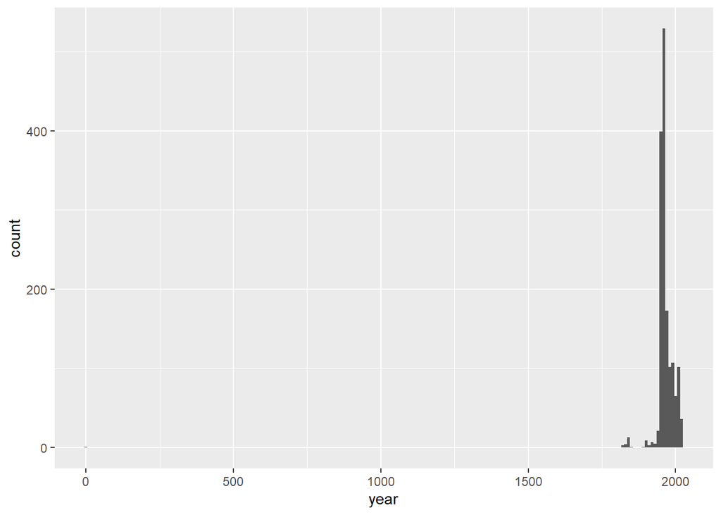

```r
ggplot(uoe_art, aes(x = year)) +
  geom_histogram(binwidth = 10)
```

Next we need to find which piece has the out of the ordinary year and go to its page on the art collection website to find the correct year for it. Can you tell why our code didn’t capture the correct year information? Correct the error in the data frame and visualize the data again.

This will give us just the piece with a year less than 1500

```r
uoe_art%>%
  filter(year < 1500)
```

```
## # A tibble: 1 x 4
##   title         artist        year date
##   <chr>         <chr>        <dbl> <chr>
## 1 "Death Mask " H. Dempshall     2 "2) "
```

This code changes the year for that one painting to the correct year

```r
uoe_art <- uoe_art %>% mutate(year = ifelse(year == 2,1964,year))
```

Finally, we can see the fix worked

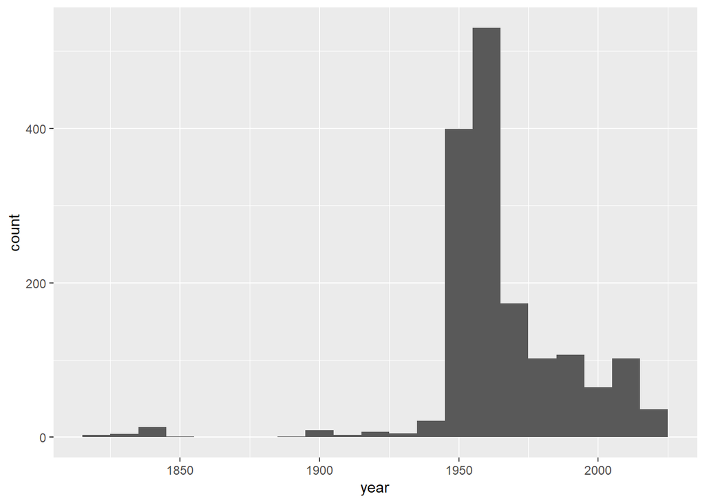

```r
ggplot(uoe_art, aes(x = year)) +
  geom_histogram(binwidth = 10)
```

Who is the most commonly featured artist in the collection? Do you know them? Any guess as to why the university has so many pieces from them?

The *count* function will simply count the number of rows each artist has in our dataset.

```r
uoe_art%>%
  count(artist, sort = TRUE)
```

```
## # A tibble: 1,115 x 2
##    artist               n
##    <chr>            <int>
##  1 Unknown            356
##  2 Emma Gillies       148
##  3 <NA>               115
##  4 John Bellany        22
##  5 Ann F Ward          19
##  6 Boris Bucan         17
##  7 Marjorie Wallace    17
##  8 Zygmunt Bukowski    17
##  9 Gordon Bryce        16
## 10 William Gillon      16
## # ... with 1,105 more rows
```

How many art pieces have the word “child” in their title? Try to figure it out, and ask for help if you’re stuck.

```r
uoe_art%>%
  filter(str_detect(title,"Child"))
```

```
## # A tibble: 11 x 4
##    title                                 artist            year date
##    <chr>                                 <chr>            <dbl> <chr>
##  1 "Child's collar. Chinese"             Unknown             NA <NA>
##  2 "Untitled - Children Playing "        Monika L I Ueck~  1963 1963)
##  3 "Virgin and Child "                   Unknown             NA statuette head ~
##  4 "Woman with Child and Still Life "    Catherine I. Mc~  1938 1938)
##  5 "Virgin and Child "                   Unknown             NA Tondo)
##  6 "Child's chinese headdress"           Unknown             NA <NA>
##  7 "Virgin and Child"                    Unknown             NA <NA>
##  8 "The Children's Hour "                Eduardo Luigi P~    NA 1974-1976)
##  9 "Figure Composition with Nurse and C~ Edward A. Gage      NA Circa 1950)
## 10 "The Sun Dissolves while Man Looks A~ Eduardo Luigi P~    NA <NA>
## 11 "Untitled - Portrait of a Woman and ~ William Gillon      NA Feb 1962)
```